# Mapping congressional districts

Steve Simon

February 22, 2018

```r
library(ggmap)
```

```r
library(ggplot2)
library(geosphere)
library(magrittr)
library(maptools)
library(rvest)
library(sf)
library(tidyverse)
library(viridis)
```

I have gotten some help from

Roger Bivand. Combining Spatial Data vignette. March 25, 2017. Available at https://cran.r-project.org/web/packages/maptools/vignettes/combine_maptools.pdf

Matt Strimas-Mackey. Tidy Spatial Data in R, Using dplyr, tidyr, and ggplot2 with sf. March 9, 2017. Available at http://strimas.com/r/tidy-sf/

Edzer Pebesma. Spatial Data in R: New Directions. July 4, 2017. Available at https://edzer.github.io/UseR2017/

Simple Features for R. Available at https://cran.r-project.org/web/packages/sf/vignettes/sf1.html

Manipulating Simple Feature Geometries. Available at https://cran.r-project.org/web/packages/sf/vignettes/sf3.html

Melanie Frazier. Overview of Coordinate Reference Systems (CRS) in R.

The file used in this example, cb_2016_us_cd115_500k.shp, was downloaded from https://www.census.gov/geo/maps-data/data/cbf/cbf_cds.html.

The 500K means that the scale is 1:500,000 which is the highest resolution available.

```r
path_name <- "~/mapping-shapefiles/shp"
list.files(path_name)
```

```
##  [1] "cb_2016_us_cd115_20m.cpg"
##  [2] "cb_2016_us_cd115_20m.dbf"
##  [3] "cb_2016_us_cd115_20m.prj"
##  [4] "cb_2016_us_cd115_20m.shp"
##  [5] "cb_2016_us_cd115_20m.shp.ea.iso.xml"
##  [6] "cb_2016_us_cd115_20m.shp.iso.xml"
##  [7] "cb_2016_us_cd115_20m.shp.xml"
##  [8] "cb_2016_us_cd115_20m.shx"
##  [9] "cb_2016_us_cd115_500k.cpg"
## [10] "cb_2016_us_cd115_500k.dbf"
## [11] "cb_2016_us_cd115_500k.prj"
## [12] "cb_2016_us_cd115_500k.shp"
## [13] "cb_2016_us_cd115_500k.shp.ea.iso.xml"
## [14] "cb_2016_us_cd115_500k.shp.iso.xml"
## [15] "cb_2016_us_cd115_500k.shp.xml"
## [16] "cb_2016_us_cd115_500k.shx"
## [17] "Townships.cpg"
## [18] "Townships.dbf"
## [19] "Townships.prj"
## [20] "Townships.shp"
## [21] "Townships.shx"
## [22] "Townships.xml"
```

```r
file_name <- "cb_2016_us_cd115_500k.shp"
path_name                              %>%
  paste(file_name, sep="/")            %>%
  st_read(stringsAsFactors=FALSE)      -> all_districts
names(all_districts)
```

```
## [1] "STATEFP"  "CD115FP"  "AFFGEOID" "GEOID"    "LSAD"     "CDSESSN"
## [7] "ALAND"    "AWATER"   "geometry"
```

We’ll start by looking at a congressional district in southern Louisiana, mostly because it has an interesting shape.

```r
la01 <- "2201"
all_districts                          %>%
  filter(GEOID==la01)                  %>%
  st_coordinates                       -> geo_matrix

head(geo_matrix)
```

```
##              X        Y L1 L2 L3
## [1,] -88.86770 29.86155  1  1  1
## [2,] -88.86566 29.86262  1  1  1
## [3,] -88.86431 29.86100  1  1  1
## [4,] -88.86348 29.85883  1  1  1
## [5,] -88.86271 29.85678  1  1  1
## [6,] -88.86207 29.85279  1  1  1
```

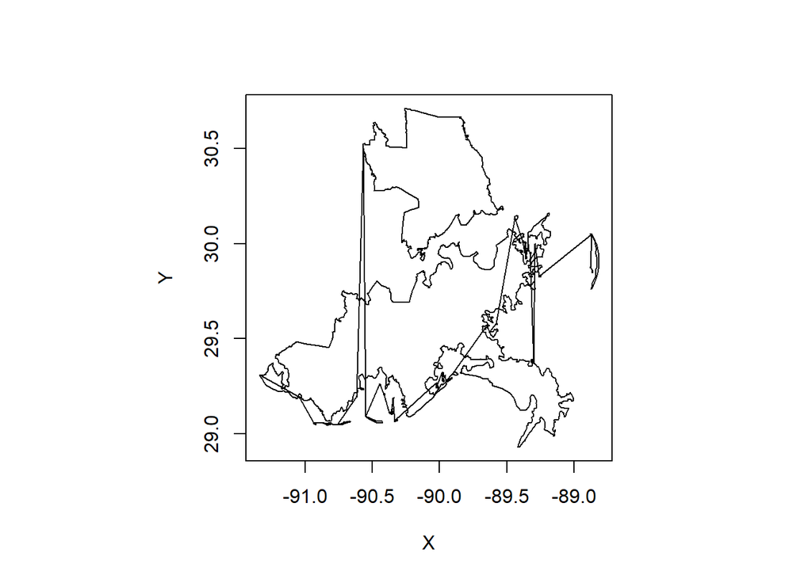

```r
par(pty="s")
plot(geo_matrix, type="l")
```

If you plot the matrix, you get a distorted picture because a degree of latitude does not represent the same distances as a degree of longitude. At the higher latitudes (closer to the north or south pole), the lines of longitude come closer together. So you need to adjust the longitude to insure that east-west distances and north-south distances appear the same.

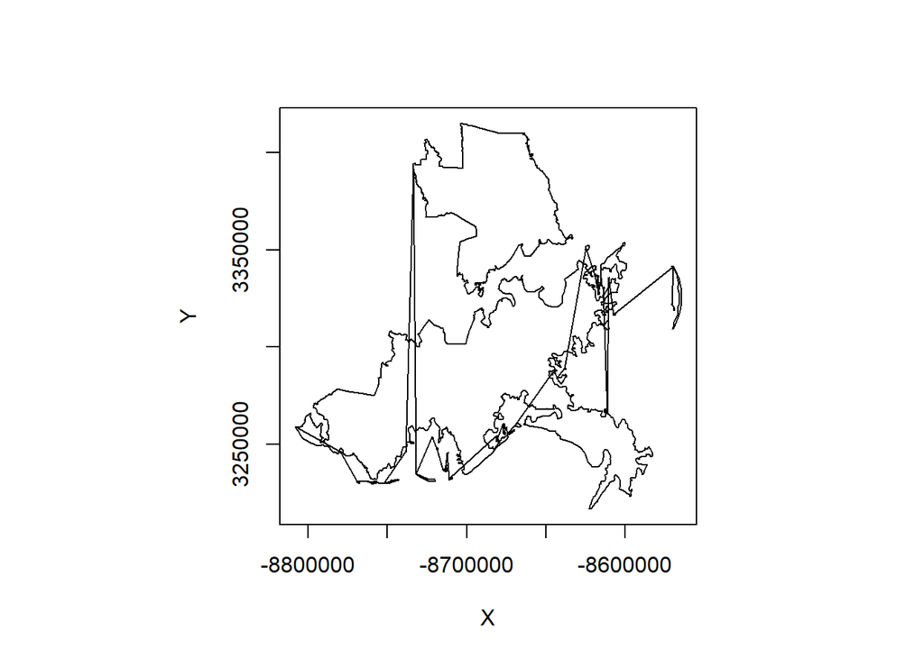

```r
convert_to_meters <- function(mat) {
  radius_earth <- 6371000
  perimeter_earth <- 2*pi*radius_earth
  degree_latitude <- perimeter_earth / 360
  meters_latitude <- mat[, "Y"]*degree_latitude
  degree_longitude <- degree_latitude*cos(mat[1, "Y"]*pi/180)
  meters_longitude <- mat[, "X"]*degree_longitude
  return(data.frame(X=meters_longitude, Y=meters_latitude))
}
geo_matrix %>% convert_to_meters -> meter_matrix

par(pty="s")
plot(meter_matrix, type="l")
```

There are a bunch of islands and the stray diagonal lines occur when the district transitions from one island to another or to the mainlaind.

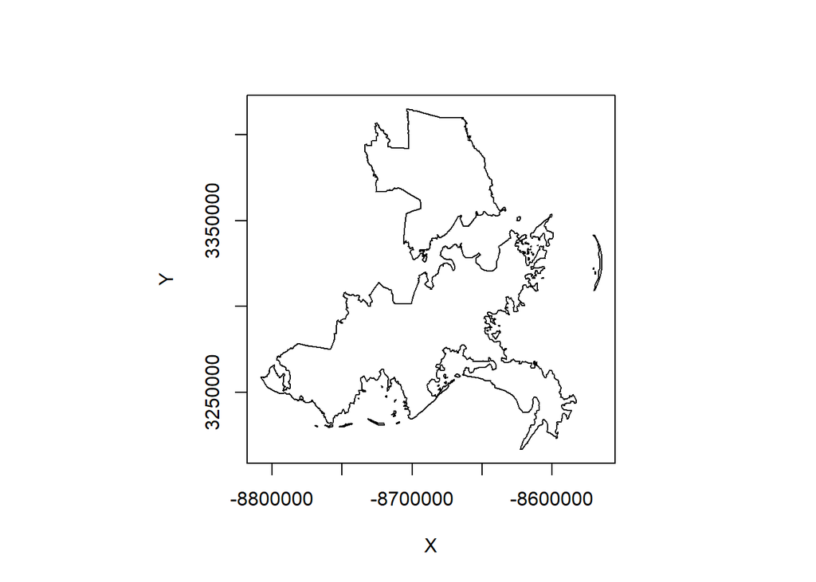

```r
par(pty="s")
plot(meter_matrix, type="n")
for (i in 1:max(geo_matrix[, "L2"])) {
  lines(meter_matrix[geo_matrix[, "L2"]==i,])
}
```

Calculating the perimeter is tricky when you have multiple polygons. You don’t want to count the length of the stray lines when you jump from one island to another.

```r
cycle <- function(x) {
  n <- length(x)
  return(x[c(2:n, 1)])
}
n <- dim(geo_matrix)[1]
dx <- rep(NA, n)
dy <- rep(NA, n)
for (i in 1:max(geo_matrix[, "L2"])) {
  ni <- which(geo_matrix[, "L2"]==i)
  dx[ni] <- meter_matrix[ni, "X"] - meter_matrix[cycle(ni), "X"]
  dy[ni] <- meter_matrix[ni, "Y"] - meter_matrix[cycle(ni), "Y"]
}
sum(sqrt(dx^2+dy^2))
```

```
## [1] 2369701
```

It’s best just to let R handle all these details. The sf library has several built in functions to handle geographic data. The st_length function will give you the perimeter of congressional district, allowing for separate islands. It is actually a bit more accurate than my earlier hand calculations, partly because is uses a “great circle” method to calculate distances and partly because it accounts for the fact that the earth is not a perfect sphere (it bulges out near the equator).

Notice how ggplot2 recognizes the geographic information and produces a nice looking graph with very little effort.

WARNING!! The geom_sf function in ggplot2 is experimental and not yet part of the regular package (at least not at the time I wrote this, February 2018). You have to install a special version of ggplot2 using the RTools package. For details, go to

https://dcl-2017-01.github.io/curriculum/notes/spatial-vis.html

and note the installation instructions at the very top of the page.

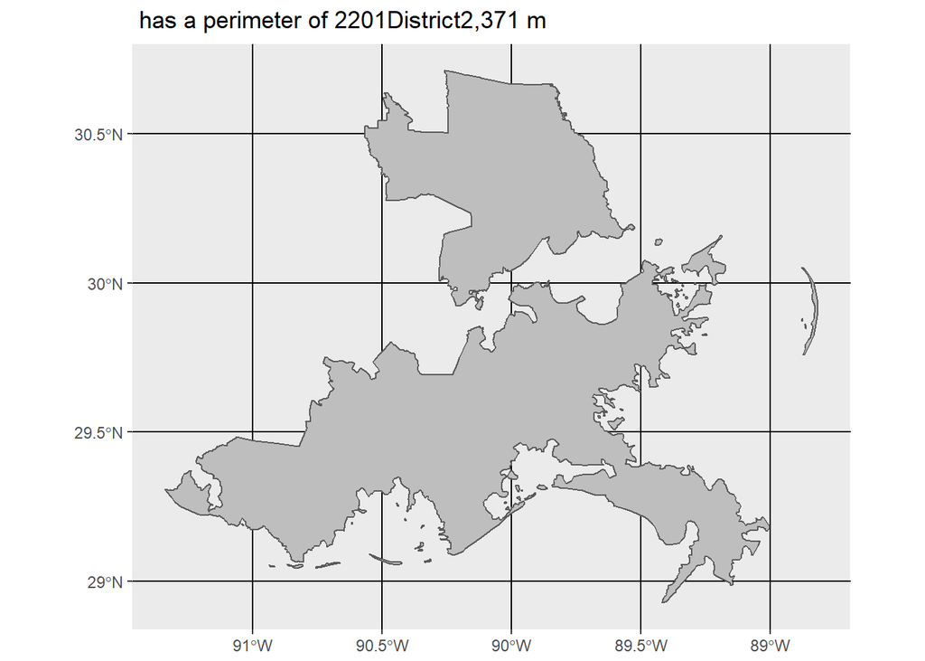

```r
all_districts                          %>%
  filter(GEOID==la01)                  %>%
  st_length                            %>%
  divide_by(1000)                      %>%
  round                                %>%
  format(big.mark=",")                 %>%
  paste0("District", .)                %>%
  paste0(la01, .)                      %>%
  paste0(" has a perimeter of ", .)    -> title_string
all_districts                          %>%
  filter(GEOID==la01)                  %>%
  ggplot()                              +
  geom_sf(fill="gray")                  +
  ggtitle(title_string)
```

Let’s do something interesting with the congressional district data. There’s been a lot of news about gerrymandering.

The ratio of the area to the perimeter squared is a simple measure of how irregular a Congressional district is. You multiply by the constant 4*pi so that the most simple geometric shape, a circle, has a ratio of 1. With this normalization constant, every shape other than a circle has a ratio less than one.

```r
all_districts$area <- st_area(all_districts)
all_districts$perimeter <- st_length(all_districts)
all_districts %<>% mutate(ratio=4*pi*area/perimeter^2) %>% arrange(ratio)
```

Here is a simple graph that displays all the Congressional districts in a state, with one particular Congressional district highlighted.

```r
highlight_district <- function(district_number) {
  state_fips_code <- substr(district_number, 1, 2)
  district_string <- as.character(district_number)
  all_districts                          %>%
    mutate(fill_color=
      ifelse(GEOID==district_number,
        district_string, "others"))      -> single_district
  single_district                        %>%
    filter(fill_color==1)                %>%
    use_series(geometry)                 %>%
    st_area                              -> district_area
  d <<- district_area
  print(district_area)
  single_district                        %>%
    filter(STATEFP==state_fips_code)     %>%
    ggplot()                              +
    geom_sf(aes(fill=fill_color))         +
    scale_fill_manual(
      values=c("gray", "white"))          +
    ggtitle(district_string)              +
    theme(legend.position="none")
}
```

Let’s start by plotting the district with the lowest area/perimeter ratio.

```r
all_districts                          %>%
  top_n(-10)                           %>%
  use_series(GEOID)                    %>%
  as.character                         -> worst_districts
highlight_district(worst_districts[1])
```

```
##  m^2
```

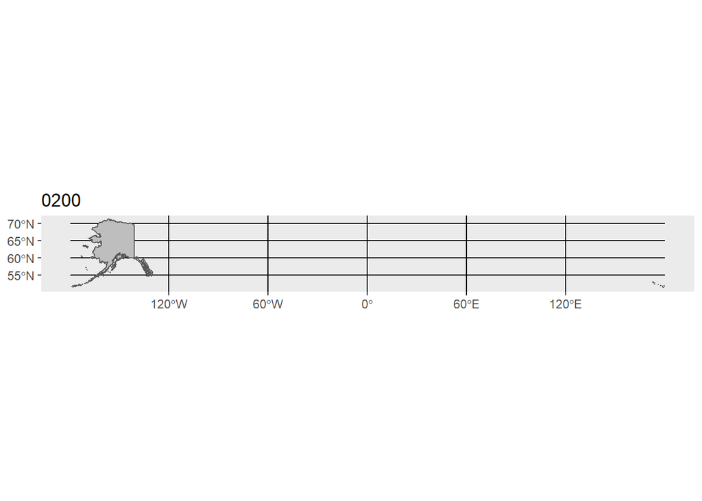

Surprise, it’s Alaska, which has only one Congressional district. Since gerrymandering is impossible in states like Alaska, you need to remove them before further analysis.

```r
all_districts                            %>%
  group_by(STATEFP)                      %>%
  summarize(n=n())                       %>%
  filter(n>1)                            %>%
  use_series(STATEFP)                    -> multirep_states

all_districts                          %>%
  filter(STATEFP %in% multirep_states) %>%
  arrange(ratio)                       -> multirep_districts

multirep_districts                     %>%
  top_n(-10)                           %>%
  use_series(GEOID)                    %>%
  as.character                         -> worst_districts
highlight_district(worst_districts[1])
```

```
##  m^2
```

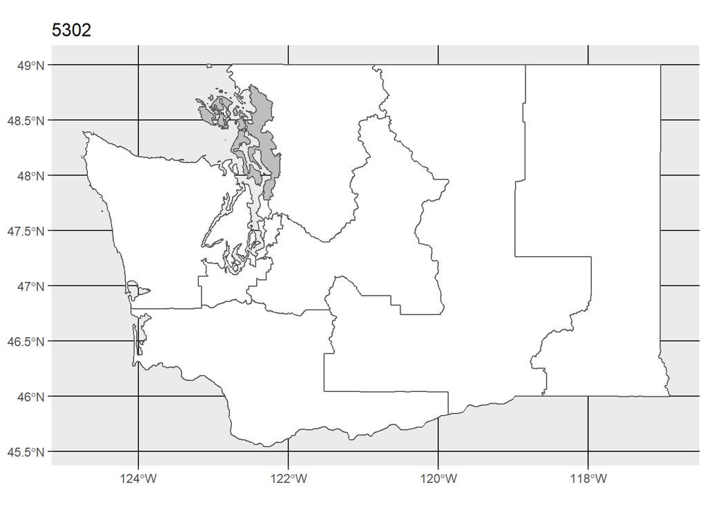

Well, that’s a very irregular shaped district, but at least half of the irregular shape was the coastline, which was drawn not by the legislatures, but by God. I would not think of accusing God of gerrymandering.

A serious solution would require you to eliminate any coastal areas from the map before considering the shape of a district. You might also eliminate the state boundaries also.

```r
all_districts                          %>%
  st_union                             -> coast_line
coast_line                             %>%
  plot
```

[output not shown]

```r
create_interior_boundaries <- function(district_number) {
  state_fips <- substr(district_number, 1, 2)
  all_districts                        %>%
    filter(STATEFP==state_fips)        %>%
    st_union                           %>%
    st_boundary                        %>%
    st_geometry                        -> state_boundary

  all_districts                        %>%
    filter(GEOID==district_number)     %>%
    select(geometry)                   %>%
    st_boundary                        %>%
    st_geometry                           -> district_boundary

  district_boundary                    %>%
    st_difference(state_boundary)      %>%
    st_segmentize(50)                  -> interior_boundary

  st_sf(
    i=letters[1:2],
    geometry=c(
      interior_boundary,
      state_boundary))

}

full_map <- create_interior_boundaries(worst_districts[1])
```

```
## although coordinates are longitude/latitude, st_difference assumes that they are planar
```

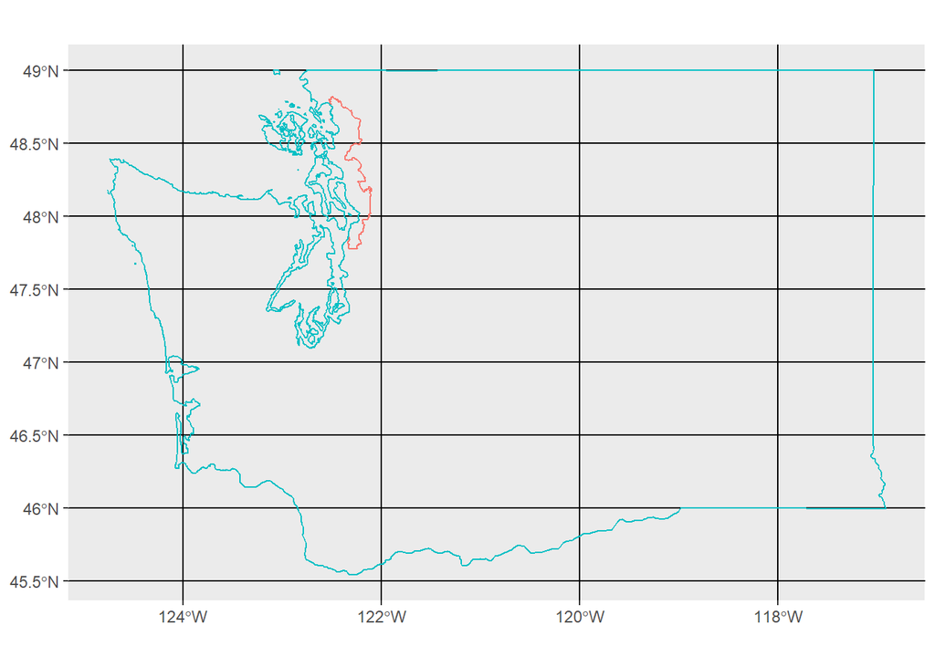

```r
full_map                               %>%
    ggplot                              +
    geom_sf(aes(color=i))               +
    theme(legend.position="none")
```

```r
for (iw in 1:10) {
  full_map <- create_interior_boundaries(worst_districts[iw])
  full_map                               %>%
    ggplot                                +
    geom_sf(aes(color=i))                 +
    theme(legend.position="none")        -> gm
  plot(gm)
}
```

[output not shown]

```r
sw_corner <- function(gmap) {
  bb <- st_bbox(gmap)
  return(data.frame(x=bb$xmin, y=bb$ymin))
}
se_corner <- function(gmap) {
  bb <- st_bbox(gmap)
  return(data.frame(x=bb$xmax, y=bb$ymin))
}
nw_corner <- function(gmap) {
  bb <- st_bbox(gmap)
  return(data.frame(x=bb$xmin, y=bb$ymax))
}
ne_corner <- function(gmap) {
  bb <- st_bbox(gmap)
  return(data.frame(x=bb$xmax, y=bb$ymax))
}
map_middle <- function(gmap) {
  bb <- st_bbox(gmap)
  mx <- (bb$xmin+bb$xmax)/2
  my <- (bb$ymin+bb$ymax)/2
  return(data.frame(x=mx, y=my))
}
make_box <- function(corners, i) {
  box_vertices <- matrix(-1, 5, 2)
  box_vertices[1,  ] <- corners[i, c("x1", "y1")]
  box_vertices[3,  ] <- corners[i, c("x3", "y3")]
  box_vertices[5,  ] <- box_vertices[1,  ]

  box_vertices[2, 1] <- box_vertices[1, 1]
  box_vertices[2, 2] <- box_vertices[3, 2]

  box_vertices[4, 1] <- box_vertices[3, 1]
  box_vertices[4, 2] <- box_vertices[5, 2]
  dimnames(box_vertices) <- list(NULL, c("x", "y"))
  return(box_vertices)
}

d1 <- distm(sw_corner(full_map[1, ]), se_corner(full_map[1, ]))
d2 <- distm(nw_corner(full_map[1, ]), ne_corner(full_map[1, ]))
d3 <- distm(sw_corner(full_map[1, ]), nw_corner(full_map[1, ]))
d4 <- distm(se_corner(full_map[1, ]), ne_corner(full_map[1, ]))
dmax <- 1.1*sqrt(2)*max(d1, d2, d3, d4)
```

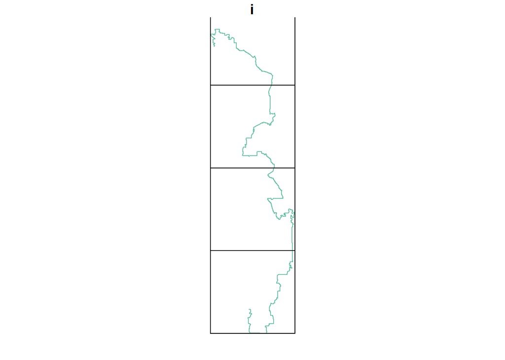

```
##
## n = 16, box count = 12
```

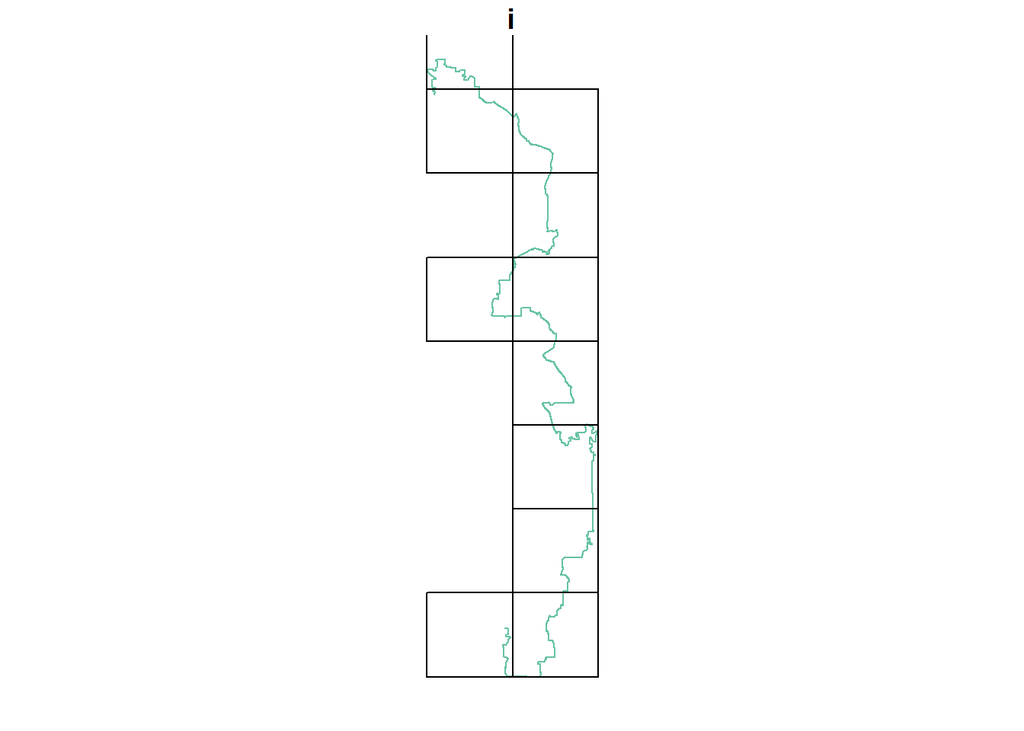

```
##
## n = 16, box count = 5
```

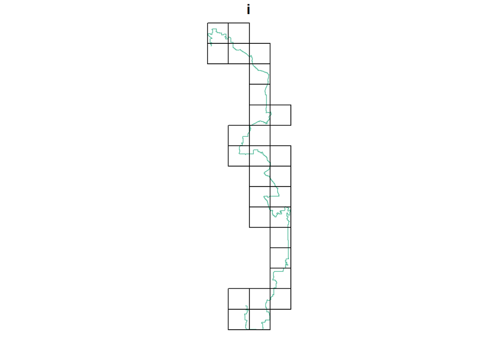

```
##
## n = 44, box count = 16
```

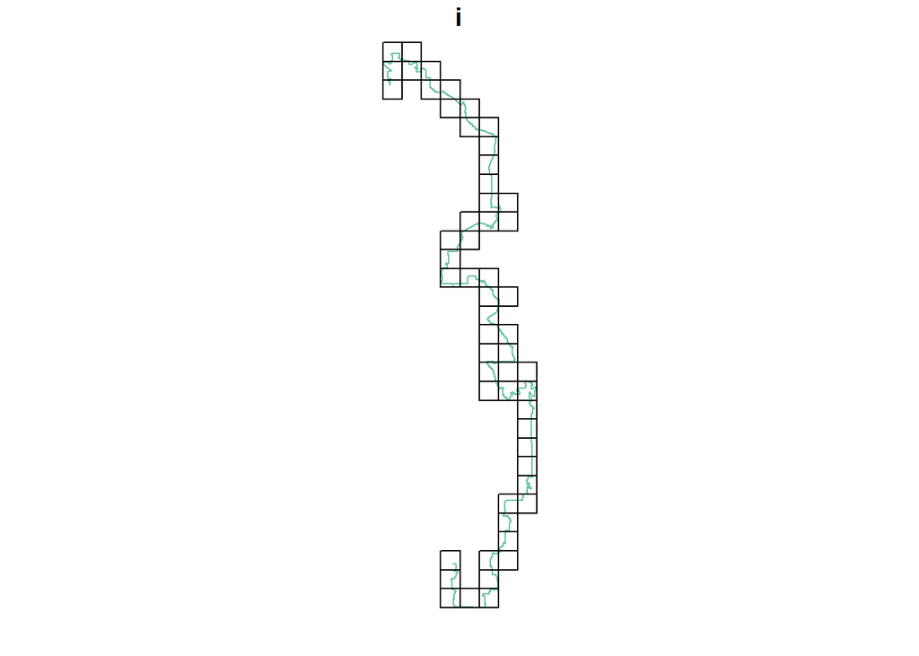

```
##
## n = 112, box count = 57
```

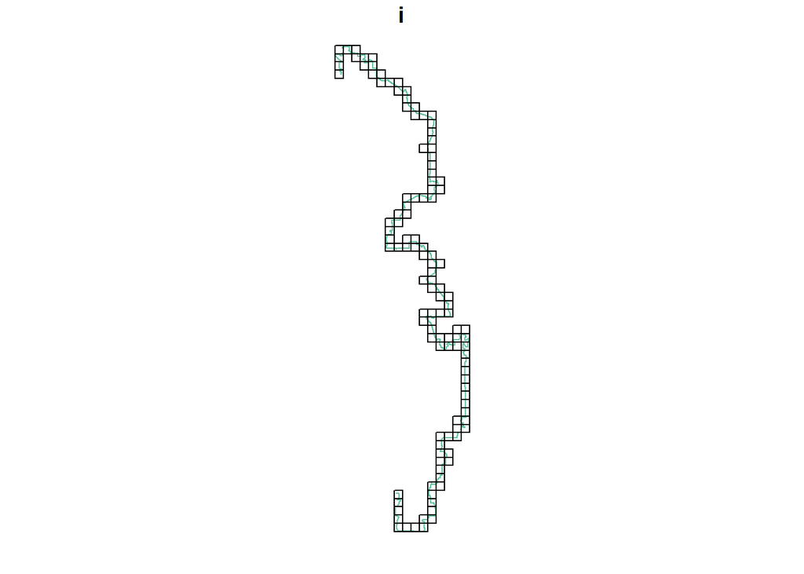

```
##
## n = 220, box count = 99
```

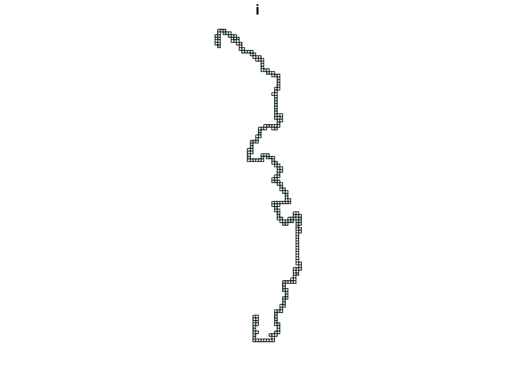

```
##
## n = 484, box count = 213
```

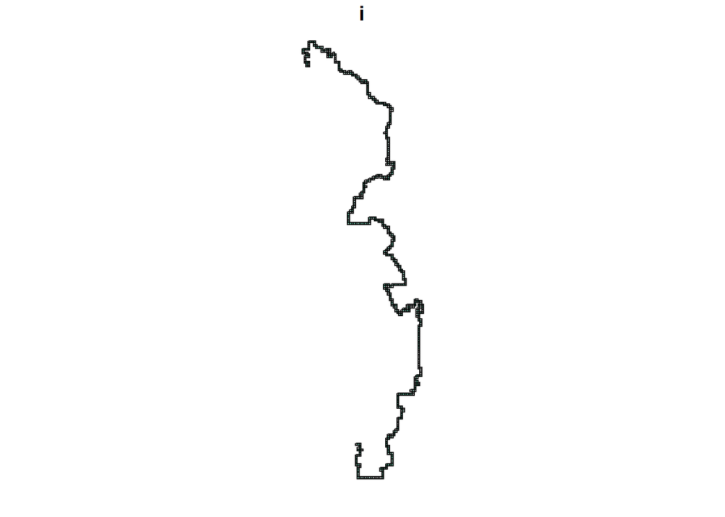

```
##
## n = 1084, box count = 516
```

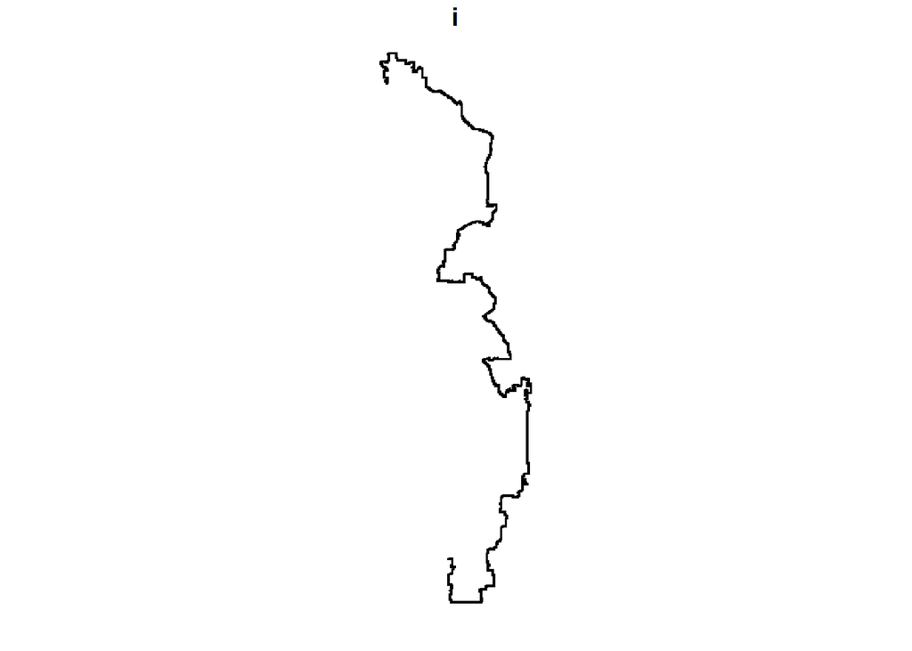

```
##
## n = 2272, box count = 1115
```

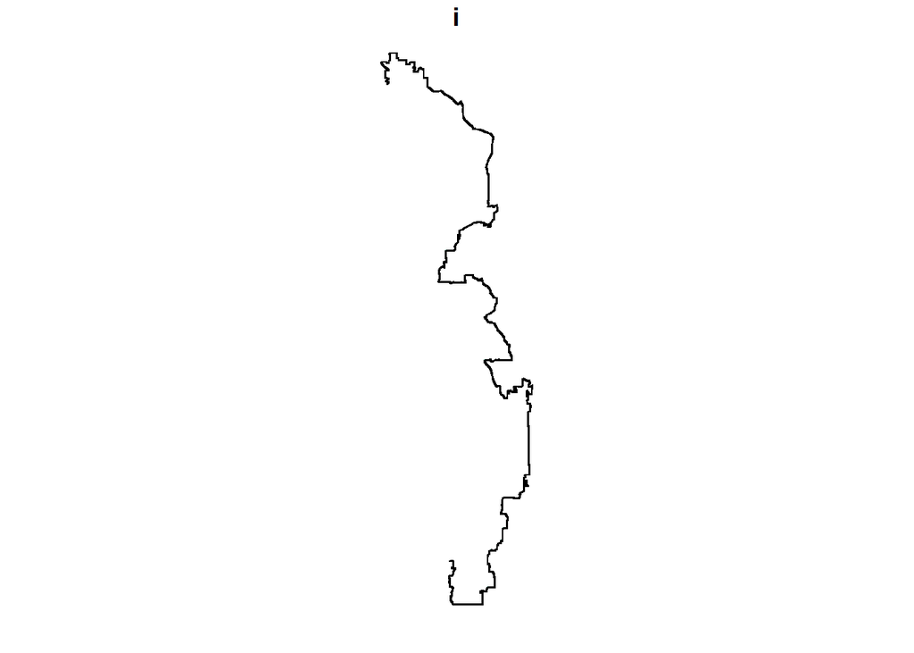

```
##
## n = 4628, box count = 2280
```

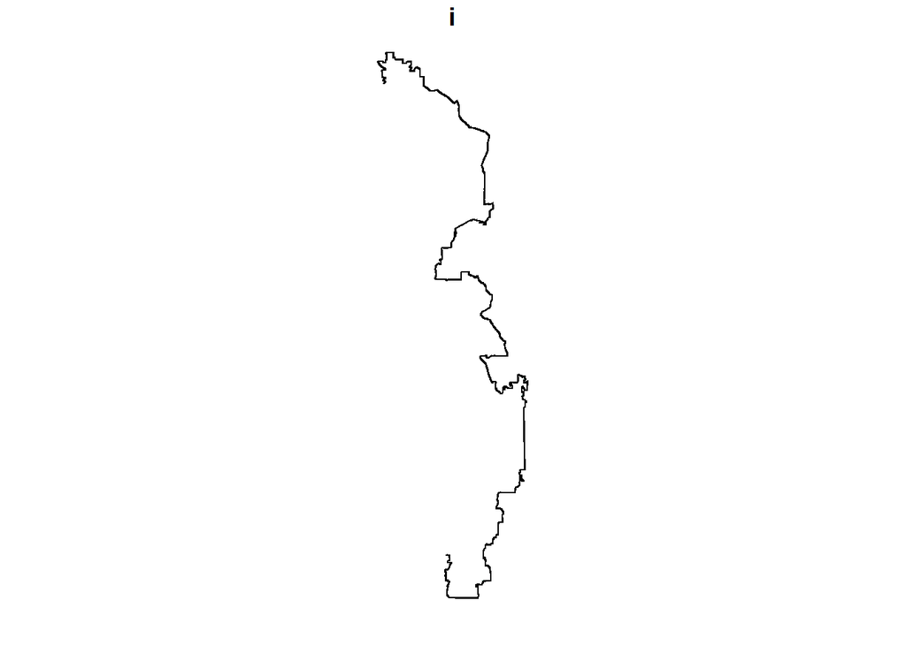

```
##
## n = 9392, box count = 4674
```

```r
corners <- matrix(-1, nrow=1, ncol=6)
dimnames(corners) <- list(NULL, c("x1", "y1", "x2", "y2", "x3", "y3"))
corners[1, c("x1", "y1")] <- unlist(sw_corner(full_map[1, ]))
corners[1, c("x3", "y3")] <- destPoint(sw_corner(full_map[1, ]), 45, dmax)
corners[1, c("x2", "y2")] <-
  (corners[1, c("x1", "y1")] +
   corners[1, c("x3", "y3")] )/ 2

quarter_split <- function(corners) {
  n <- dim(corners)[1]
  new_corners <- matrix(-1, 4*n, 6)
  dimnames(new_corners)[[2]] <-
    c("x1", "y1", "x2", "y2", "x3", "y3")

  new_corners[4*(1:n)-3, "x1"] <- corners[ , "x1"]
  new_corners[4*(1:n)-3, "y1"] <- corners[ , "y1"]
  new_corners[4*(1:n)-3, "x3"] <- corners[ , "x2"]
  new_corners[4*(1:n)-3, "y3"] <- corners[ , "y2"]

  new_corners[4*(1:n)-2, "x1"] <- corners[ , "x1"]
  new_corners[4*(1:n)-2, "y1"] <- corners[ , "y2"]
  new_corners[4*(1:n)-2, "x3"] <- corners[ , "x2"]
  new_corners[4*(1:n)-2, "y3"] <- corners[ , "y3"]

  new_corners[4*(1:n)-1, "x1"] <- corners[ , "x2"]
  new_corners[4*(1:n)-1, "y1"] <- corners[ , "y1"]
  new_corners[4*(1:n)-1, "x3"] <- corners[ , "x3"]
  new_corners[4*(1:n)-1, "y3"] <- corners[ , "y2"]

  new_corners[4*(1:n)  , "x1"] <- corners[ , "x2"]
  new_corners[4*(1:n)  , "y1"] <- corners[ , "y2"]
  new_corners[4*(1:n)  , "x3"] <- corners[ , "x3"]
  new_corners[4*(1:n)  , "y3"] <- corners[ , "y3"]

  new_corners[ , c("x2", "y2")] <-
    (new_corners[ , c("x1", "y1")] +
     new_corners[ , c("x3", "y3")]) / 2
  return(new_corners)
}
# The 1.1 is a fudge factor to insure that the entire graph is covered.
corners <- quarter_split(corners)
for (i in 1:10 ) {
corners <- quarter_split(corners)
par(pty="s")
n <- dim(corners)[1]
relate_code <- rep("XXX", n)
for (i in 1:n) {
  boxi <- st_polygon(list(make_box(corners, i)))
  relate_code[i] <- st_relate(boxi, full_map[1, ])
}
corners <- corners[relate_code!="FF2FF1102", ]
plot(full_map[1, ])
for (i in 1:dim(corners)[1]) {lines(make_box(corners, i))}
cat("\nn = ")
cat(n)
cat(", box count = ")
cat(sum(relate_code=="FF2FF1102"))
}
```

Save everything for possible later use.

```r
save.image("~/mapping-shapefiles/data/congress.RData")
```